# Reshaping Data

This tutorial introduces the `tidyr` package for reshaping data in R. `tidyr` is written by [Hadley Wickham](http://had.co.nz/) and can be installed from CRAN using the `install.packages()` function. The GitHub page for the project is found here: https://github.com/hadley/tidyr.

This tutorial will cover the following topics about the `tidyr` package:

- Reshaping with `gather()`
- Reshaping with `spread()`
- How to recognize long and wide formats

## Reshaping with `gather()`

Often we have data in a format that is not convenient for a certain purpose. Below is an example of a data frame that is in a wide format. This data frame contains made up data for 8 hour maximum values in parts per million from 4 different monitors over 4 consecutive days.

```r
ozone_wide <- read.table(header=TRUE, text='
  day  monitor1  monitor2   monitor3  monitor4
    1     0.029     0.040      0.010     0.032
    2     0.025     0.050      0.015     0.041
    3     0.030     0.045      0.012     0.040
    4     0.031     0.052      0.019     0.041
                       ')
```

Now suppose we wanted to plot this data frame using the `ggplot2` package. In the wide format, we can only plot one column at a time.

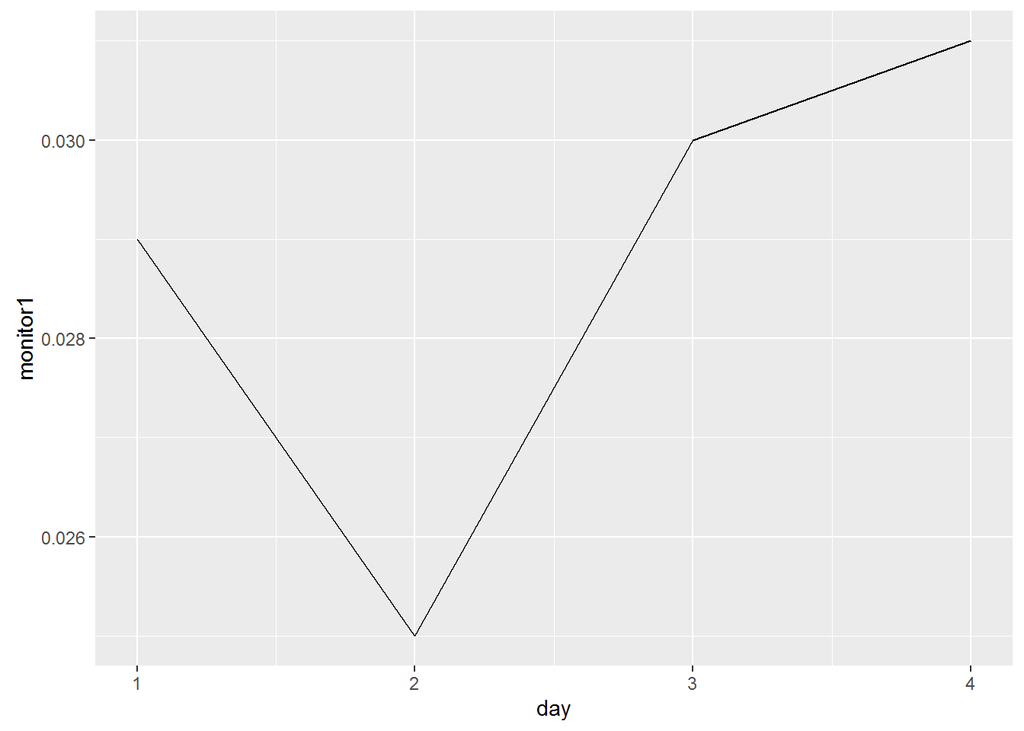

```r
library(ggplot2)

ggplot(ozone_wide, aes(day, monitor1)) + geom_line()
```

We could easily plot all of the values from each monitor in a `ggplot2` graph if all of the values were stacked in one column. Again, right now the data frame is *wide*. We want the values to be all in one column, a *long* format. We want to gather the monitor columns in, so we use the `tidyr` function called `gather()`.

```r
library(tidyr)
ozone_long <- gather(ozone_wide, key = "monitor", value = "ppm", monitor1:monitor4)
ozone_long
```

```
##    day  monitor   ppm
## 1    1 monitor1 0.029
## 2    2 monitor1 0.025
## 3    3 monitor1 0.030
## 4    4 monitor1 0.031
## 5    1 monitor2 0.040
## 6    2 monitor2 0.050
## 7    3 monitor2 0.045
## 8    4 monitor2 0.052
## 9    1 monitor3 0.010
## 10   2 monitor3 0.015
## 11   3 monitor3 0.012
## 12   4 monitor3 0.019
## 13   1 monitor4 0.032
## 14   2 monitor4 0.041
## 15   3 monitor4 0.040
## 16   4 monitor4 0.041
```

The first parameter in `gather()` is the data frame (just like every function in `dplyr`). The second parameter is the name we want to give to the column that will contain all of the monitor column names in the `ozone_wide` data frame. The second parameter is the name we want to give to the column that will have all of the numeric values. The last parameter specifies what columns we want to gather. The colon means that we want to gather the “monitor1” column, the “monitor4” column, and all of the columns in between.

Now we can easily plot all of the values.

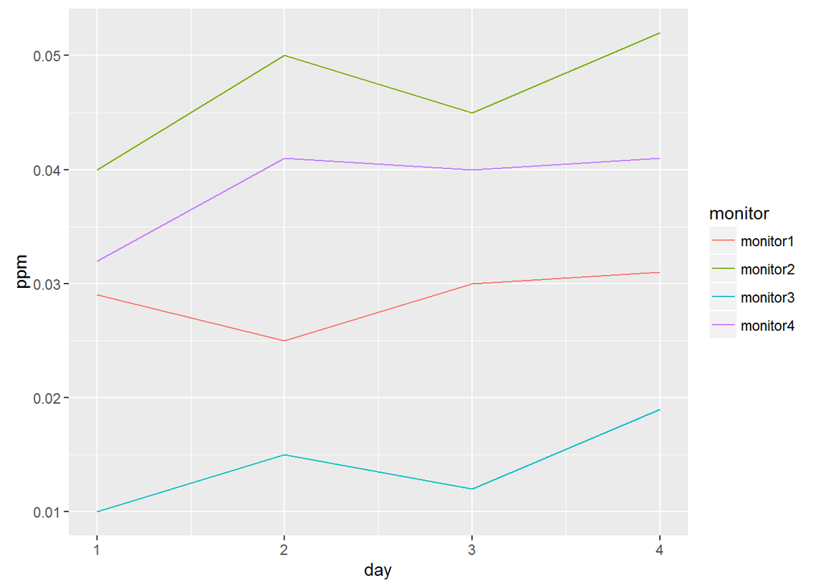

```r
ggplot(ozone_long, aes(day, ppm, color = monitor)) + geom_line()
```

## Reshaping with spread()

Of course, if you have a data frame in a long format you may actually want it in a wide format. In this case, you have all of your values stacked in one long column and you want to spread those values out. We use the `spread()` function from `tidyr` to do this. In this example we simply take the long data frame we just created and reshape it back into a wide format.

```r
spread(ozone_long, key = "monitor", value = "ppm")
```

```
##   day monitor1 monitor2 monitor3 monitor4
## 1   1    0.029    0.040    0.010    0.032
## 2   2    0.025    0.050    0.015    0.041
## 3   3    0.030    0.045    0.012    0.040
## 4   4    0.031    0.052    0.019    0.041
```

The parameters are the same as `gather()`, except we don’t have to supply the columns we want to create–that information is contained within the `key`.

## How to recognize long and wide formats

It may be difficult to figure out what shape your data is in. The best way to figure out the shape of a data frame is to determine if there is a natural key or not. A natural key is a column in your data frame that uniquely represents each row in the data frame and does not repeat. If your data frame has a column that is a natural key, then your data is in a wide format. If your data frame doesn’t have a natural key, it’s in a long format.

Let’s look at `ozone_wide`.

```r
ozone_wide
```

```
##   day monitor1 monitor2 monitor3 monitor4
## 1   1    0.029    0.040    0.010    0.032
## 2   2    0.025    0.050    0.015    0.041
## 3   3    0.030    0.045    0.012    0.040
## 4   4    0.031    0.052    0.019    0.041
```

“day” is a column that uniquely identifies each row of the data frame and doesn’t repeat. There is a single day 1, a single day 2, etc.

`ozone_long` doesn’t have a column that is a natural key.

```r
ozone_long
```

```
##    day  monitor   ppm
## 1    1 monitor1 0.029
## 2    2 monitor1 0.025
## 3    3 monitor1 0.030
## 4    4 monitor1 0.031
## 5    1 monitor2 0.040
## 6    2 monitor2 0.050
## 7    3 monitor2 0.045
## 8    4 monitor2 0.052
## 9    1 monitor3 0.010
## 10   2 monitor3 0.015
## 11   3 monitor3 0.012
## 12   4 monitor3 0.019
## 13   1 monitor4 0.032
## 14   2 monitor4 0.041
## 15   3 monitor4 0.040
## 16   4 monitor4 0.041
```

Each day is repeated several times.

Wide formats are easy to identify and easy to reshape to a long format. Long formats are more difficult to identify and more difficult to reshape. You must recognize that there is no key, and you must figure out which column *should* be the key.

## Exercises

Exercises for this tutorial can be found here: http://rpubs.com/NateByers/ReshapingExercises.